# 4.3vis_tech

Huize Zhang

08/07/2019

```r
library(tidyverse)
load("raw_data/ci_count.rda")
load("raw_data/court.rda")
load("raw_data/au_imputed.rda")
load("raw_data/sim_result.rda")
load("raw_data/au_aggregate.rda")
```

# Task 1: Distribution by Judge:

## Does the judge behave consistently across the videos?

## Are there any abnormal moment during one video for a particular judge?

Since we only have a few cases for each judge, simulation study is more suitable here.

# Task 2: Comparison of judges

## Does the judge behave the same or different from one to another?

We have a couple of cases for each judge while have way more action unit variables to learn the question, thus it is high-dimension problem

What are the most commonly detected action unit among all? - Look at the second plot! AU02, AU15, AU20, AU14 are the pretty common across all the judges. However, are these the most influential ones that makes one judge differentiate from another? Probably not: It is like everyone sitting here has a bachelor degree making holding a bachelor degree less useful to evaluate everyone’s ability.

Thus we perform PCA to find the most influential and thus the most “animated” judge.

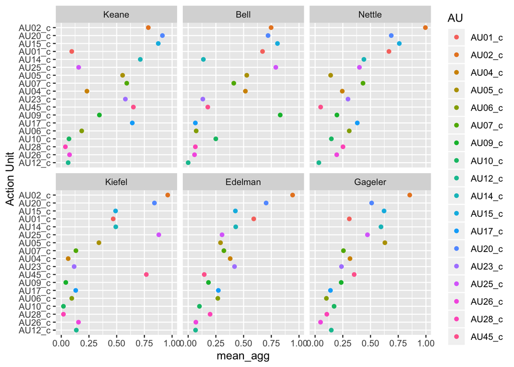

```r
# need a better fct_reorder way to order Action Unit
by_judge <- au_aggregate %>%
  left_join(sim_result, by = c("judge_id", "AU")) %>%
  arrange(judge_id, mean_agg) %>%
  group_by(judge_id)

by_judge %>%
  group_by(judge_id)%>%
  mutate(mean_judge = mean(mean_agg)) %>%
  ggplot(aes(x = mean_agg,
             y = fct_reorder(AU, mean_agg),
             col = AU)) +
  geom_point() +
  facet_wrap(vars(fct_reorder(judge_id, mean_judge, .desc = TRUE))) +
  ylab("Action Unit")
```

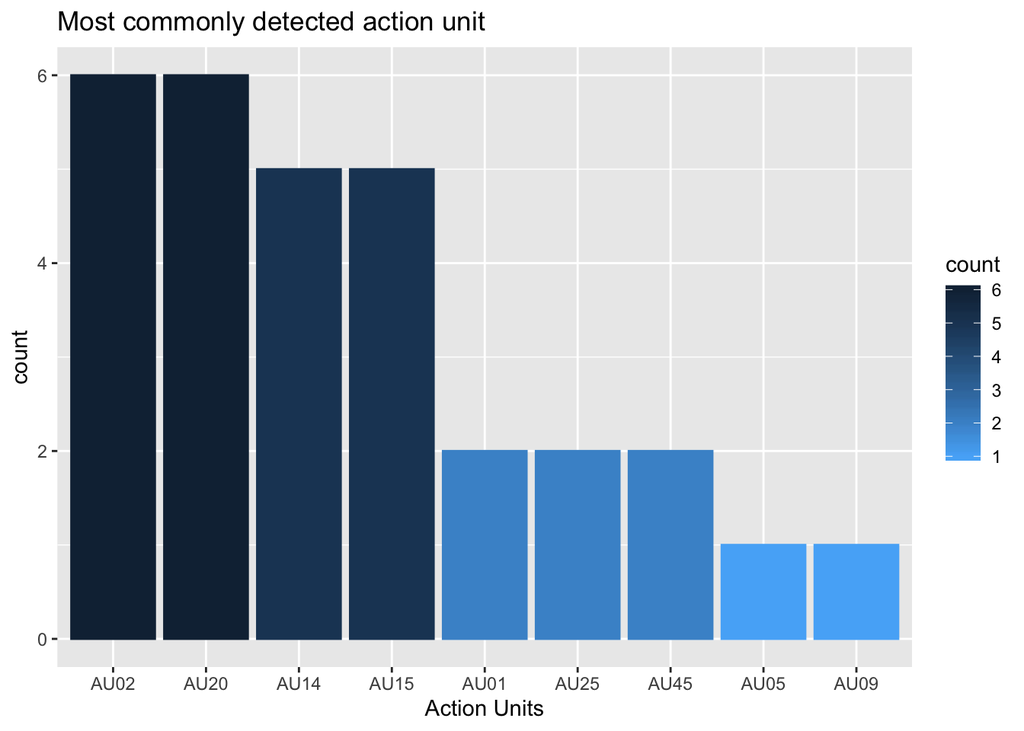

```r
# top 5 action unit by judge
by_judge %>%
  top_n(5, wt = mean_agg) %>%
  group_by(AU) %>%
  summarise(count = n()) %>%
  mutate(AU = str_sub(AU, end = 4)) %>%
  ggplot(aes(x = fct_reorder(AU, count, .desc = TRUE),
             y = count, col = count, fill = count)) +
  geom_bar(stat = "identity") +
  scale_fill_continuous(high = "#132B43", low = "#56B1F7") +
  scale_color_continuous(high = "#132B43", low = "#56B1F7") + #reverse the color scale
  xlab("Action Units") +
  ggtitle("Most commonly detected action unit")
```

Who is the most animated judge?

The top 10 PCs explains 94.5% of the variance and we have plotted the first two PCs and can see that some judges’ behaviour are quite different from others i.e. Bell, Gageler, Kiefel. We also plot to see the most influential variables and find that this time, AU45, AU09, AU06, AU17 and AU04 are the most influential ones!

Question to answer: Who is the most animated judge? Since PCs are linear combination of the original variables, we take the absolute value of fitted PCs and add them up to create an index. The larger the index is, the more animated the judge is (the influencial action units are presented more often in these judges).

```r
library(broom)
# PCA doesnt allow for judge_id and video_id, so save a copy of them, compute pca and then add the two indices back
summarised_mean <- au_imputed %>%
  select(-speaker, -frame_id) %>%
  group_by(judge_id, video_id) %>%
  summarise_all(mean, na.rm = TRUE) %>%
  filter(AU01_c != "NaN")

pca_data <- summarised_mean %>%
  ungroup() %>%
  select(-judge_id, -video_id)

pca_model <- pca_data %>%
  nest() %>%
  mutate(model = map(data, ~prcomp(.x)))

# vis: variance explained: top 10 PCs explains 94.5% of the variance - happy with that
p1 <- pca_model$model %>%
  map_df(~tidy(.x, data = .y, "pcs")) %>%
  ggplot(aes(x = PC, y = cumulative)) +
  geom_line() +
  geom_point() # 9 or 10 principal component is fine

pca_aug <- pca_model %>%
  mutate(pca_aug = map2(model, data, ~augment(.x, data = .y))) %>%
  unnest(pca_aug) %>%
  bind_cols(summarised_mean[, 1:2])

# PCA vis
p2 <- pca_aug %>%
  ggplot(aes(x = .fittedPC1, y = .fittedPC2, col = judge_id)) +
  geom_point()

# seems that there's an "outliner" in the data for Bell: this is in video OKS
pca_aug %>% select(.fittedPC1, .fittedPC2, judge_id, video_id) %>% filter(judge_id == "Bell")
```

```
## # A tibble: 3 x 4
##   .fittedPC1 .fittedPC2 judge_id video_id
##        <dbl>      <dbl> <chr>    <fct>
## 1      0.814    0.00626 Bell     McKell
## 2      1.39     1.14    Bell     OKS
## 3      0.841    0.0795  Bell     Parkes
```

```r
# Most important variables
library(factoextra)
pca_subset <- prcomp(pca_data)

p3 <- fviz_pca_var(pca_subset,
             col.var = "contrib", # Color by contributions to the PC
             gradient.cols = c("#00AFBB", "#E7B800", "#FC4E07"),
             repel = TRUE     # Avoid text overlapping
             )

pca_model$model[[1]]$rotation %>%
  as_tibble() %>%
  bind_cols(AU = colnames(pca_data)) %>%
  arrange(PC1, PC2) %>%
  select(AU, PC1, PC2)
```

```
## # A tibble: 35 x 3
##    AU        PC1      PC2
##    <chr>   <dbl>    <dbl>
##  1 AU17_r -0.287  0.175
##  2 AU20_r -0.263 -0.0106
##  3 AU06_r -0.251  0.310
##  4 AU17_c -0.205  0.128
##  5 AU14_r -0.193  0.0375
##  6 AU07_c -0.155  0.105
##  7 AU02_c -0.138 -0.00644
##  8 AU23_r -0.125  0.0800
##  9 AU15_r -0.122 -0.0302
## 10 AU20_c -0.112  0.0781
## # … with 25 more rows
```

```r
# Most animated judge
most_animated_judge <- pca_aug %>%
  select(.fittedPC1: .fittedPC10) %>%
  as.matrix() %>%
  abs() %>%
  as.data.frame() %>%
  bind_cols(judge_id = pca_aug$judge_id,
            video_id = pca_aug$video_id) %>%
  group_by(judge_id) %>%
  summarise_all(mean) %>% # summarise into one judge per row (from one judge*video per row)
  ungroup() %>%
  mutate(index = select(., .fittedPC1: .fittedPC2) %>% rowSums()) %>%
  select(judge_id, index) %>%
  arrange(desc(index)) # ignore the warning message

most_animated_judge
```

```
## # A tibble: 6 x 2
##   judge_id index
##   <chr>    <dbl>
## 1 Bell     1.42
## 2 Kiefel   1.04
## 3 Nettle   0.909
## 4 Gageler  0.863
## 5 Keane    0.815
## 6 Edelman  0.535
```

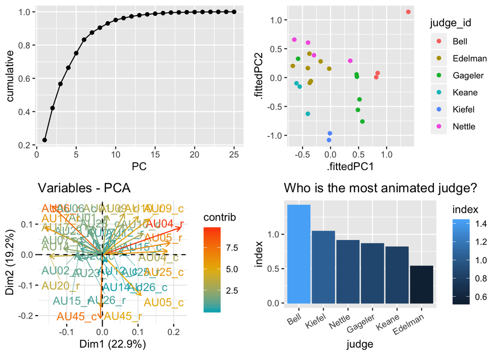

```r
p4 <- most_animated_judge %>%
  ggplot(aes(x = fct_reorder(judge_id, desc(index)),
             y = index, col = index, fill = index)) +
  geom_bar(stat = "identity") +
  theme(axis.text.x = element_text(angle = 30, hjust = 1)) +
  xlab("judge") +
  ggtitle("Who is the most animated judge?")

gridExtra::grid.arrange(p1, p2,p3,p4)
```

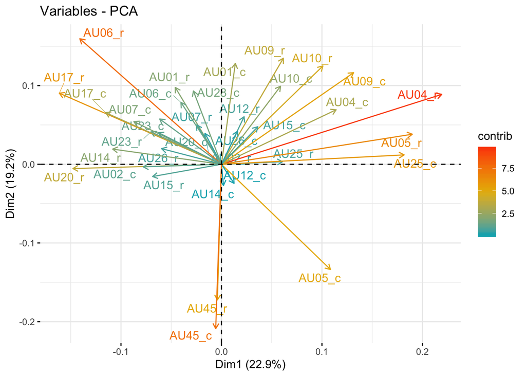

```r
g <- gridExtra::arrangeGrob(p1, p2,p3,p4) #generates g
ggsave(file="images/pca.png", g)

p3
```

Penalsd LDA/ LASSO maybe in class variable

# Task 3. Incorporating Time dimension

[figure not shown]

```r
# need to figure out how to arrange the graph
load("raw_data/ci_intensity.rda")
au_sim_frame <- au_imputed %>%
  select(AU01_r: AU45_r, judge_id :speaker) %>%
  gather(AU, value, -(judge_id: speaker))%>%
  left_join(ci_intensity) %>%
  mutate(significant = as.factor(ifelse(value > sim_high, 1, 0)))


temp <- au_sim_frame %>%
  filter(value != "NA",
         AU %in% c("AU45_r", "AU09_r", "AU06_r", "AU17_r", "AU04_r"),
         judge_id == "Keane") %>%
  ggplot(aes(x = frame_id, y = value,col = significant)) +
  geom_point() +
  facet_grid(video_id~AU, scales = "free") +
  geom_hline(aes(yintercept= sim_high), col = "gray")

temp
```

```r
ggsave("task3.png")
```